# Cyclistic Case Study

Marc Tan

2/12/2022

# Company Overview

In 2016, Cyclistic launched a successful bike-share offering. Since then, the program has grown to a fleet of 5,824 bicycles that are geotracked and locked into a network of 692 stations across Chicago. The bikes can be unlocked from one station and returned to any other station in the system anytime.

Until now, Cyclistic’s marketing strategy relied on building general awareness and appealing to broad consumer segments. One approach that helped make these things possible was the flexibility of its pricing plans: single-ride passes, full-day passes, and annual memberships. Customers who purchase single-ride or full-day passes are referred to as casual riders. Customers who purchase annual memberships are Cyclistic members.

# Ask

The problem that we would like to solve is how casual users would lean more into becoming Cyclistic members. In other words, increase numbers for their annual membership.

This case study will also try to determine key differences of usage between casual and Cyclistic members.

The following data are collected from this [link](https://divvy-tripdata.s3.amazonaws.com/index.html). I will use the csv files that are dated during the year 2020.

The stakeholders for this project will be the Marketing team, Lily Moreno(Manager), the analytics team, and the executive team.

# Prepare

First, I imported to Google Sheets the latest data that I downloaded from the link provided by the course for the past year and made sure to check if the data is clean by checking for duplicates and removing whitespace.I will also add a filter and check if there are blanks, NA, or irregular values.

I also imported the csv in **RStudio** and installed the necessary packages to check for duplicates

```r
#install.packages("tidyverse")
#install.packages("dplyr")
#install.packages("geosphere")
#install.packages("ggplot2")
library(tidyverse)
library(dplyr)
library(geosphere)
library(ggplot2)
```

```r
cyclistic_april_2020 <- read.csv("../202004-divvy-tripdata.csv")
cyclistic_may_2020 <- read.csv("../202005-divvy-tripdata.csv")
cyclistic_june_2020 <- read.csv("../202006-divvy-tripdata.csv")
cyclistic_july_2020 <- read.csv("../202007-divvy-tripdata.csv")
cyclistic_august_2020 <- read.csv("../202008-divvy-tripdata.csv")
cyclistic_september_2020 <- read.csv("../202009-divvy-tripdata.csv")
cyclistic_october_2020 <- read.csv("../202010-divvy-tripdata.csv")
cyclistic_november_2020 <- read.csv("../202011-divvy-tripdata.csv")
cyclistic_december_2020 <- read.csv("../202012-divvy-tripdata.csv")
cyclistic_q1_2020 <- read.csv("../Divvy_Trips_2020_Q1.csv")
```

I would then check the structure and format of the data of their properly formatted using:

str() colnames() glimpse()

```r
str(cyclistic_q1_2020)
```

```
## 'data.frame':    426887 obs. of  13 variables:
##  $ ride_id           : chr  "EACB19130B0CDA4A" "8FED874C809DC021" "789F3C21E472CA96" "C9A388DAC6ABF313" ...
##  $ rideable_type     : chr  "docked_bike" "docked_bike" "docked_bike" "docked_bike" ...
##  $ started_at        : chr  "2020-01-21 20:06:59" "2020-01-30 14:22:39" "2020-01-09 19:29:26" "2020-01-06 16:17:07" ...
##  $ ended_at          : chr  "2020-01-21 20:14:30" "2020-01-30 14:26:22" "2020-01-09 19:32:17" "2020-01-06 16:25:56" ...
##  $ start_station_name: chr  "Western Ave & Leland Ave" "Clark St & Montrose Ave" "Broadway & Belmont Ave" "Clark St & Randolph St" ...
##  $ start_station_id  : int  239 234 296 51 66 212 96 96 212 38 ...
##  $ end_station_name  : chr  "Clark St & Leland Ave" "Southport Ave & Irving Park Rd" "Wilton Ave & Belmont Ave" "Fairbanks Ct & Grand Ave" ...
##  $ end_station_id    : int  326 318 117 24 212 96 212 212 96 100 ...
##  $ start_lat         : num  42 42 41.9 41.9 41.9 ...
##  $ start_lng         : num  -87.7 -87.7 -87.6 -87.6 -87.6 ...
##  $ end_lat           : num  42 42 41.9 41.9 41.9 ...
##  $ end_lng           : num  -87.7 -87.7 -87.7 -87.6 -87.6 ...
##  $ member_casual     : chr  "member" "member" "member" "member" ...
```

```r
colnames(cyclistic_q1_2020)
```

```
##  [1] "ride_id"            "rideable_type"      "started_at"
##  [4] "ended_at"           "start_station_name" "start_station_id"
##  [7] "end_station_name"   "end_station_id"     "start_lat"
## [10] "start_lng"          "end_lat"            "end_lng"
## [13] "member_casual"
```

```r
glimpse(cyclistic_q1_2020)
```

```
## Rows: 426,887
## Columns: 13
## $ ride_id            <chr> "EACB19130B0CDA4A", "8FED874C809DC021", "789F3C21E4~
## $ rideable_type      <chr> "docked_bike", "docked_bike", "docked_bike", "docke~
## $ started_at         <chr> "2020-01-21 20:06:59", "2020-01-30 14:22:39", "2020~
## $ ended_at           <chr> "2020-01-21 20:14:30", "2020-01-30 14:26:22", "2020~
## $ start_station_name <chr> "Western Ave & Leland Ave", "Clark St & Montrose Av~
## $ start_station_id   <int> 239, 234, 296, 51, 66, 212, 96, 96, 212, 38, 117, 1~
## $ end_station_name   <chr> "Clark St & Leland Ave", "Southport Ave & Irving Pa~
## $ end_station_id     <int> 326, 318, 117, 24, 212, 96, 212, 212, 96, 100, 632,~
## $ start_lat          <dbl> 41.9665, 41.9616, 41.9401, 41.8846, 41.8856, 41.889~
## $ start_lng          <dbl> -87.6884, -87.6660, -87.6455, -87.6319, -87.6418, -~
## $ end_lat            <dbl> 41.9671, 41.9542, 41.9402, 41.8918, 41.8899, 41.884~
## $ end_lng            <dbl> -87.6674, -87.6644, -87.6530, -87.6206, -87.6343, -~
## $ member_casual      <chr> "member", "member", "member", "member", "member", "~
```

```r
glimpse(cyclistic_april_2020)
```

```
## Rows: 84,776
## Columns: 13
## $ ride_id            <chr> "A847FADBBC638E45", "5405B80E996FF60D", "5DD24A79A4~
## $ rideable_type      <chr> "docked_bike", "docked_bike", "docked_bike", "docke~
## $ started_at         <chr> "2020-04-26 17:45:14", "2020-04-17 17:08:54", "2020~
## $ ended_at           <chr> "2020-04-26 18:12:03", "2020-04-17 17:17:03", "2020~
## $ start_station_name <chr> "Eckhart Park", "Drake Ave & Fullerton Ave", "McClu~
## $ start_station_id   <int> 86, 503, 142, 216, 125, 173, 35, 434, 627, 377, 508~
## $ end_station_name   <chr> "Lincoln Ave & Diversey Pkwy", "Kosciuszko Park", "~
## $ end_station_id     <int> 152, 499, 255, 657, 323, 35, 635, 382, 359, 508, 37~
## $ start_lat          <dbl> 41.8964, 41.9244, 41.8945, 41.9030, 41.8902, 41.896~
## $ start_lng          <dbl> -87.6610, -87.7154, -87.6179, -87.6975, -87.6262, -~
## $ end_lat            <dbl> 41.9322, 41.9306, 41.8679, 41.8992, 41.9695, 41.892~
## $ end_lng            <dbl> -87.6586, -87.7238, -87.6230, -87.6722, -87.6547, -~
## $ member_casual      <chr> "member", "member", "member", "member", "casual", "~
```

*Do the rest for the months (May-December)*

Mutating start_station_id and and end_station_id to chr type

```r
cyclistic_q1_2020 <- mutate(cyclistic_q1_2020, start_station_id= as.character(start_station_id), end_station_id= as.character(end_station_id))
```

```r
cyclistic_april_2020 <- mutate(cyclistic_april_2020, start_station_id= as.character(start_station_id), end_station_id= as.character(end_station_id))
```

```r
cyclistic_may_2020 <- mutate(cyclistic_may_2020, start_station_id= as.character(start_station_id), end_station_id= as.character(end_station_id))
```

```r
cyclistic_june_2020 <- mutate(cyclistic_june_2020, start_station_id= as.character(start_station_id), end_station_id= as.character(end_station_id))
```

```r
cyclistic_july_2020 <- mutate(cyclistic_july_2020, start_station_id= as.character(start_station_id), end_station_id= as.character(end_station_id))
```

```r
cyclistic_august_2020 <- mutate(cyclistic_august_2020, start_station_id= as.character(start_station_id), end_station_id= as.character(end_station_id))
```

```r
cyclistic_september_2020 <- mutate(cyclistic_september_2020, start_station_id= as.character(start_station_id), end_station_id= as.character(end_station_id))
```

```r
cyclistic_october_2020 <- mutate(cyclistic_october_2020, start_station_id= as.character(start_station_id), end_station_id= as.character(end_station_id))
```

```r
cyclistic_november_2020 <- mutate(cyclistic_november_2020, start_station_id= as.character(start_station_id), end_station_id= as.character(end_station_id))
```

```r
cyclistic_december_2020 <- mutate(cyclistic_december_2020, start_station_id= as.character(start_station_id), end_station_id= as.character(end_station_id))
```

```r
#Binding all rows to one data frame for 2020
cyclistic_2020 <- bind_rows(cyclistic_q1_2020, cyclistic_april_2020, cyclistic_may_2020, cyclistic_june_2020, cyclistic_july_2020, cyclistic_august_2020, cyclistic_september_2020, cyclistic_october_2020, cyclistic_november_2020, cyclistic_december_2020)
```

# Process

Start by looking for missing values in start and end station id

```r
cyclistic_2020 %>%
     filter(is.na(start_station_id)) %>%
     count(start_station_id, start_station_name, sort = TRUE)
```

```
##   start_station_id               start_station_name     n
## 1             <NA>                                  82957
## 2             <NA>       W Oakdale Ave & N Broadway   482
## 3             <NA> W Armitage Ave & N Sheffield Ave   139
## 4             <NA>                 hubbard_test_lws     3
## 5             <NA>            N Clark St & W Elm St     1
## 6             <NA>      S Michigan Ave & E 118th St     1
```

```r
cyclistic_2020 %>%
     filter(is.na(end_station_id)) %>%
     count(end_station_id, end_station_name, sort = TRUE)
```

```
##   end_station_id                 end_station_name     n
## 1           <NA>                                  97644
## 2           <NA>       W Oakdale Ave & N Broadway   367
## 3           <NA> W Armitage Ave & N Sheffield Ave    92
## 4           <NA>                 hubbard_test_lws     2
```

Then look for specific start and end station names so we know what id to assign to missing values.

```r
cyclistic_2020 %>% filter(start_station_name == "W Oakdale Ave & N Broadway" |
                             start_station_name == "W Armitage Ave & N Sheffield Ave" |
                             start_station_name == "N Clark St & W Elm St" |
                             start_station_name == "S Michigan Ave & E 118th St") %>%
     count(start_station_id, start_station_name, sort=TRUE)
```

```
##   start_station_id               start_station_name   n
## 1             <NA>       W Oakdale Ave & N Broadway 482
## 2             <NA> W Armitage Ave & N Sheffield Ave 139
## 3          20252.0       W Oakdale Ave & N Broadway  41
## 4          20254.0 W Armitage Ave & N Sheffield Ave   5
## 5             <NA>            N Clark St & W Elm St   1
## 6             <NA>      S Michigan Ave & E 118th St   1
```

```r
cyclistic_2020 %>% filter(end_station_name == "W Oakdale Ave & N Broadway" |
                               end_station_name == "W Armitage Ave & N Sheffield Ave") %>%
     count(end_station_id, end_station_name, sort=TRUE)
```

```
##   end_station_id                 end_station_name   n
## 1           <NA>       W Oakdale Ave & N Broadway 367
## 2           <NA> W Armitage Ave & N Sheffield Ave  92
## 3        20252.0       W Oakdale Ave & N Broadway  30
## 4        20254.0 W Armitage Ave & N Sheffield Ave   5
```

Then we assign and is to the start and end station names that have missing station ids.

```r
cyclistic_2020 <- cyclistic_2020 %>%
     mutate(start_station_id = ifelse(start_station_name == "W Oakdale Ave & N Broadway" & is.na(start_station_id), "20252.0", start_station_id),
            start_station_id = ifelse(start_station_name == "W Armitage Ave & N Sheffield Ave" & is.na(start_station_id), "20254.0", start_station_id),
            start_station_id = ifelse(start_station_name == "N Clark St & W Elm St" & is.na(start_station_id), "20249.0", start_station_id),
            start_station_id = ifelse(start_station_name == "S Michigan Ave & E 118th St" & is.na(start_station_id), "20209", start_station_id))
```

```r
cyclistic_2020 <- cyclistic_2020 %>%
     mutate(end_station_id = ifelse(end_station_name == "W Oakdale Ave & N Broadway" & is.na(end_station_id),
                                    "20252.0", end_station_id),
            end_station_id = ifelse(end_station_name == "W Armitage Ave & N Sheffield Ave" & is.na(end_station_id),
                                    "20254.0", end_station_id))
```

Separate date to month, day, year

```r
cyclistic_2020$date <- as.Date(cyclistic_2020$started_at)
cyclistic_2020$month <- format(as.Date(cyclistic_2020$date), "%m")
cyclistic_2020$day <- format(as.Date(cyclistic_2020$date), "%d")
cyclistic_2020$year <- format(as.Date(cyclistic_2020$date), "%Y")
cyclistic_2020$day_of_week <- format(as.Date(cyclistic_2020$date), "%A")
```

```r
#Then calculate ride length in seconds
cyclistic_2020$ride_length <- difftime(cyclistic_2020$ended_at,cyclistic_2020$started_at)
```

Count how many has negative in ride_length

```r
#Count how many has negative in ride_length
count(cyclistic_2020, ride_length < 0)
```

```
##   ride_length < 0       n
## 1           FALSE 3531018
## 2            TRUE   10665
```

```r
#There are 10665 negative values for ride lengths which is not possible.
```

```r
#Then we drop NA values
cyclistic_clean_2020 <- drop_na(cyclistic_2020)
```

```r
#I remove the rows with negative ride length by filtering them out.
cyclistic_clean_2020 <- filter(cyclistic_2020, ride_length > 0)
```

```r
#Create a data frame for negative value for ride length
negative_ride_length <- cyclistic_clean_2020 %>% select(ride_length, started_at, ended_at, start_station_name, end_station_name) %>%
     filter(ride_length <0)
```

```r
#Remove rows that contain HQ QR on their station names because they are brought for testing
cyclistic_clean_2020 <- cyclistic_clean_2020[!(
cyclistic_clean_2020$start_station_name == "HQ QR" |
cyclistic_clean_2020$end_station_name == "HQ QR"), ]
```

# Analyze

Assigning a variable for number of rides and average duration per week

```r
rides_duration_week <- cyclistic_clean_2020 %>%
     group_by(member_casual, day_of_week) %>%
     summarise(number_of_rides = n(), average_duration = mean(ride_length)) %>%
     arrange(member_casual, day_of_week)
```

I filter out the negative values in all the ride_length to maintain consistency.

```r
cyclistic_clean_2020v2 <- cyclistic_clean_2020 %>%
    filter(ride_length > 0)
```

Check again if it looks okay

```r
avg_duration_per_day <- cyclistic_clean_2020v2 %>%
group_by(member_casual, day_of_week) %>%
summarise(number_of_rides = n(), average_duration = mean(ride_length)) %>%
arrange(member_casual, day_of_week)
```

After the data is cleaned and columns were added, the data frame can now be analyzed.

Plot the average duration for the week per member type

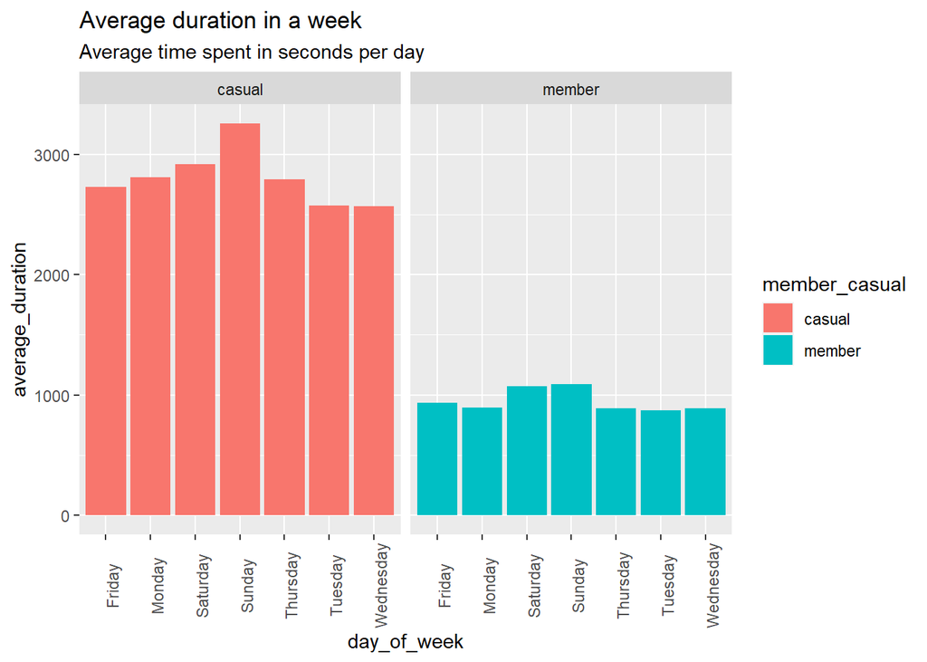

```r
ggplot(avg_duration_per_day) +
        geom_col(mapping = aes(x = day_of_week, y = average_duration, fill = member_casual)) +
        facet_wrap(~member_casual) +
labs(title = "Average duration in a week", subtitle = "Average time spent in seconds per day") +
    theme(axis.text.x = element_text(angle = 90))
```

```r
#Compute the average ride_length per member type
avg_ride_length <- cyclistic_clean_2020v2 %>%
    group_by(member_casual) %>%
    summarise(avg_time = mean(ride_length))
```

Plot data for both data frames

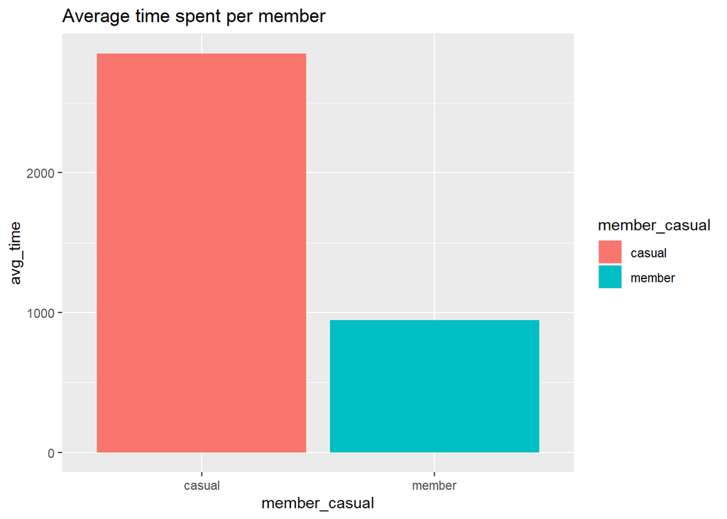

```r
ggplot(avg_ride_length) +
        geom_col(mapping = aes(x = member_casual, y = avg_time, fill = member_casual)) +
labs(title = "Average time spent per member")
```

Chart shows that casual users spend more time riding the bike compared to members that are subscribed to the service.

```r
#Check what types of ride are used per type of user
 ride_type_per_user <- cyclistic_clean_2020v2 %>%
     group_by(rideable_type)%>%
     count(member_casual)
```

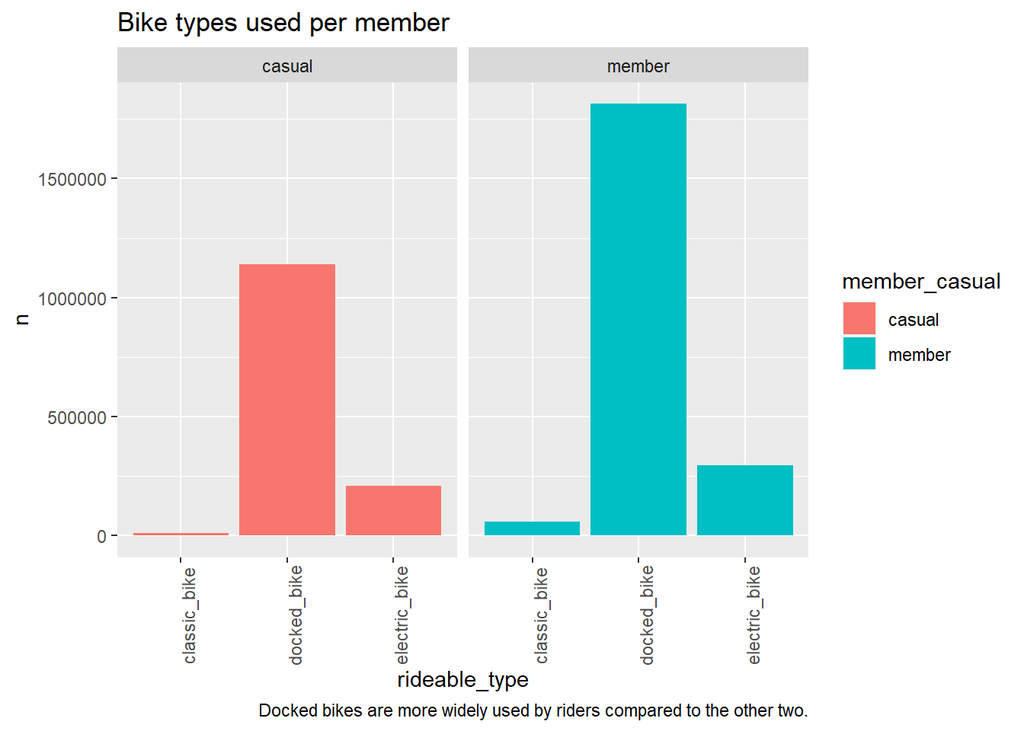

```r
ggplot(ride_type_per_user) +
        geom_col(mapping = aes(x = rideable_type, y = n, fill = member_casual))+
        facet_wrap(~member_casual)+
theme(axis.text.x = element_text(angle = 90)) +
labs(title = "Bike types used per member", caption = "Docked bikes are more widely used by riders compared to the other two.")
```

```r
#Number of rides starting from the start_station
cyclistic_clean_2020v2 %>%
filter(start_station_name != "") %>%
group_by(start_station_name) %>%
summarise(num_rides = n()) %>%
arrange(desc(num_rides))
```

```
## # A tibble: 693 x 2
##    start_station_name         num_rides
##    <chr>                          <int>
##  1 Streeter Dr & Grand Ave        35238
##  2 Clark St & Elm St              31807
##  3 Theater on the Lake            29322
##  4 Lake Shore Dr & Monroe St      29105
##  5 Lake Shore Dr & North Blvd     26511
##  6 Wells St & Concord Ln          25003
##  7 Indiana Ave & Roosevelt Rd     24582
##  8 Millennium Park                24226
##  9 Dearborn St & Erie St          24187
## 10 Columbus Dr & Randolph St      23860
## # ... with 683 more rows
```

```r
#Number of rides ending in end_station
cyclistic_clean_2020 %>%
filter(end_station_name != "") %>%
group_by(end_station_name) %>%
summarise(num_rides = n()) %>%
arrange(desc(num_rides))
```

```
## # A tibble: 693 x 2
##    end_station_name           num_rides
##    <chr>                          <int>
##  1 Streeter Dr & Grand Ave        37648
##  2 Clark St & Elm St              31874
##  3 Theater on the Lake            30910
##  4 Lake Shore Dr & Monroe St      28336
##  5 Lake Shore Dr & North Blvd     27028
##  6 Millennium Park                25612
##  7 Wells St & Concord Ln          25323
##  8 Dearborn St & Erie St          24660
##  9 Broadway & Barry Ave           24579
## 10 St. Clair St & Erie St         24297
## # ... with 683 more rows
```

Plot the data of number of ride per member type during the week

```r
rides_per_day <- cyclistic_clean_2020v2 %>%
group_by(day_of_week, member_casual) %>%
summarise(num_of_rides = n(), .groups = "drop")
```

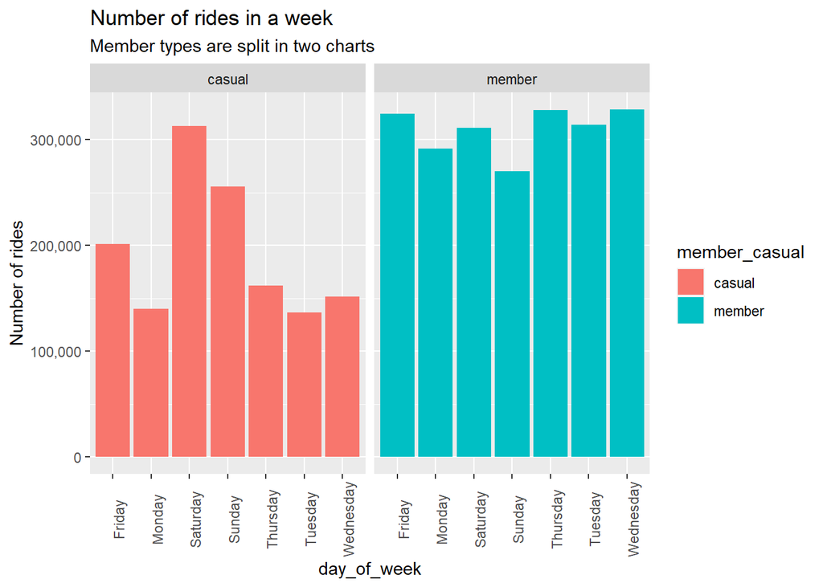

```r
ggplot(rides_per_day) +
    geom_col(mapping = aes(x = day_of_week, y = num_of_rides, fill = member_casual)) +
    facet_wrap(~member_casual) +
    theme(axis.text.x = element_text(angle = 90)) +
    labs(title = "Number of rides in a week", subtitle = "Member types are split in two charts") +
    scale_y_continuous(name = "Number of rides", labels = scales::comma)
```

Annual members use the bikes more during the week indicating that they mostly use it for going to work/school, etc. While more casual members use it over the weekend which could be used for pleasure.

Plot the data of number of ride per member type per month

```r
rides_per_month <- cyclistic_clean_2020v2 %>%
     group_by(month, member_casual) %>%
     summarise(num_of_rides = n(), .groups = "drop")
```

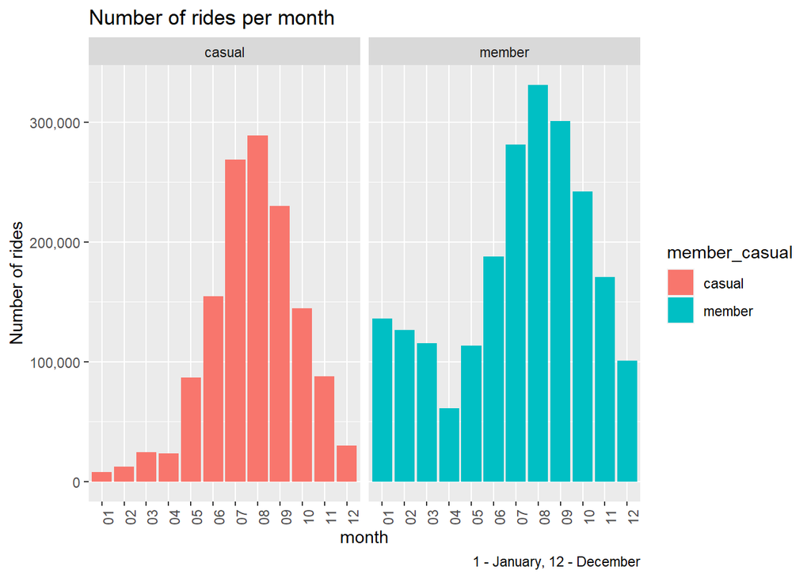

```r
ggplot(rides_per_month) +
geom_col(mapping = aes(x = month, y = num_of_rides, fill = member_casual)) +
facet_wrap(~member_casual) +
theme(axis.text.x = element_text(angle = 90)) +
labs(title = "Number of rides per month", caption = "1 - January, 12 - December") +
scale_y_continuous(name = "Number of rides", labels = scales::comma)
```

# Recommendations

I would suggest that it would help if I know how much the prices are for the single ride and subscription as it can be a deciding factor to be an annual member.

There’s also more users during the summer. The company can start a promotion during the summer where the user count is at its peak. I would also consider lower non-member rates during the off-peak months (ex. January to April).